# Evaluating Laptop Price by Features

Author

Affiliation

Liv Erickson

Columbia University

Published

October 12, 2024

Abstract

This project explores the relationship between laptop features and price.

**Show packages**

```r
library(readr)
library(kableExtra)
library(tidyr)
library(ggplot2)
library(dplyr)
library(scales)
library(tidyverse)
library(rsample)
library(recipes)
library(parsnip)
library(workflows)
library(yardstick)
library(dials)
library(tune)
library(coefplot)
library(reactable)
library(ggthemes)
library(broom)
library(patchwork)
```

# 1 Data

This project utilizes a [machine-learning optimized](https://www.kaggle.com/datasets/owm4096/laptop-prices?resource=download) dataset from Kaggle, created from a [human-readable](https://www.kaggle.com/datasets/muhammetvarl/laptop-price/) dataset that includes a number of features that may impact the price of a laptop. The data set was downloaded from Kaggle.com. The dataset contains 1275 rows and 23 columns.

I chose this dataset because I was interested to learn more about what factors influence the cost of a laptop, and there were a lot of potential areas to explore given the number of features of the dataset.

To simplify the labels on the plots, a subsection of the laptops are used in the visualization section to improve readability.

```r
laptops <- read_csv('laptop_prices.csv', show_col_types = FALSE)
feature_names <-names(laptops)
reactable(laptops)
```

| Company | Product | TypeName | Inches | Ram | OS | Weight | Price_euros | Screen | ScreenW | ScreenH | Touchscreen | IPSpanel | RetinaDisplay | CPU_company | CPU_freq | CPU_model | PrimaryStorage | SecondaryStorage | PrimaryStorageType | SecondaryStorageType | GPU_company | GPU_model |
| --- | --- | --- | --- | --- | --- | --- | --- | --- | --- | --- | --- | --- | --- | --- | --- | --- | --- | --- | --- | --- | --- | --- |
| Apple | MacBook Pro | Ultrabook | 13.3 | 8 | macOS | 1.37 | 1339.69 | Standard | 2560 | 1600 | No | Yes | Yes | Intel | 2.3 | Core i5 | 128 | 0 | SSD | No | Intel | Iris Plus Graphics 640 |
| Apple | Macbook Air | Ultrabook | 13.3 | 8 | macOS | 1.34 | 898.94 | Standard | 1440 | 900 | No | No | No | Intel | 1.8 | Core i5 | 128 | 0 | Flash Storage | No | Intel | HD Graphics 6000 |
| HP | 250 G6 | Notebook | 15.6 | 8 | No OS | 1.86 | 575 | Full HD | 1920 | 1080 | No | No | No | Intel | 2.5 | Core i5 7200U | 256 | 0 | SSD | No | Intel | HD Graphics 620 |
| Apple | MacBook Pro | Ultrabook | 15.4 | 16 | macOS | 1.83 | 2537.45 | Standard | 2880 | 1800 | No | Yes | Yes | Intel | 2.7 | Core i7 | 512 | 0 | SSD | No | AMD | Radeon Pro 455 |
| Apple | MacBook Pro | Ultrabook | 13.3 | 8 | macOS | 1.37 | 1803.6 | Standard | 2560 | 1600 | No | Yes | Yes | Intel | 3.1 | Core i5 | 256 | 0 | SSD | No | Intel | Iris Plus Graphics 650 |
| Acer | Aspire 3 | Notebook | 15.6 | 4 | Windows 10 | 2.1 | 400 | Standard | 1366 | 768 | No | No | No | AMD | 3 | A9-Series 9420 | 500 | 0 | HDD | No | AMD | Radeon R5 |
| Apple | MacBook Pro | Ultrabook | 15.4 | 16 | Mac OS X | 2.04 | 2139.97 | Standard | 2880 | 1800 | No | Yes | Yes | Intel | 2.2 | Core i7 | 256 | 0 | Flash Storage | No | Intel | Iris Pro Graphics |
| Apple | Macbook Air | Ultrabook | 13.3 | 8 | macOS | 1.34 | 1158.7 | Standard | 1440 | 900 | No | No | No | Intel | 1.8 | Core i5 | 256 | 0 | Flash Storage | No | Intel | HD Graphics 6000 |
| Asus | ZenBook UX430UN | Ultrabook | 14 | 16 | Windows 10 | 1.3 | 1495 | Full HD | 1920 | 1080 | No | No | No | Intel | 1.8 | Core i7 8550U | 512 | 0 | SSD | No | Nvidia | GeForce MX150 |
| Acer | Swift 3 | Ultrabook | 14 | 8 | Windows 10 | 1.6 | 770 | Full HD | 1920 | 1080 | No | Yes | No | Intel | 1.6 | Core i5 8250U | 256 | 0 | SSD | No | Intel | UHD Graphics 620 |

[output cut: 1265 more lines]

```r
# Remove some companies for easier graphing
graph_laptops <- laptops[!laptops$Company %in% c("Acer", "Chuwi", "Fujitsu",  "Huawei", "Mediacom", "Vero", "Xiaomi"), ]
```

# 2 Exploratory Data Analysis

## 2.1 Examining laptops by type

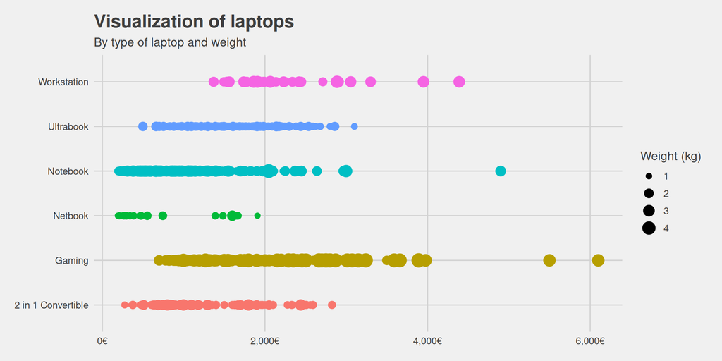

```r
ggplot(graph_laptops, aes(y=TypeName, x=Price_euros)) +
  geom_point(aes(size=Weight, color=TypeName)) + labs(
    title = 'Visualization of laptops',
    subtitle = 'By type of laptop and weight'
  ) + theme_fivethirtyeight() + theme(
    legend.position = 'right',
    legend.direction='vertical') +
  scale_x_continuous(labels = dollar_format(suffix="€", prefix = "")) +
  ylab('Price in Euros') + guides(
    color='none',
    size=guide_legend('Weight (kg)')
  )
```

From the above plot, we can see some trends in laptops related to type, weight, and price. Gaming laptops are significantly heavier than all other types of laptops, and have a wide range in terms of price. Ultrabooks weigh less than other types of laptops relative to their cost. Further plotting exercises could break down the weight based on characteristics, such as GPU manufacturer or screen size.

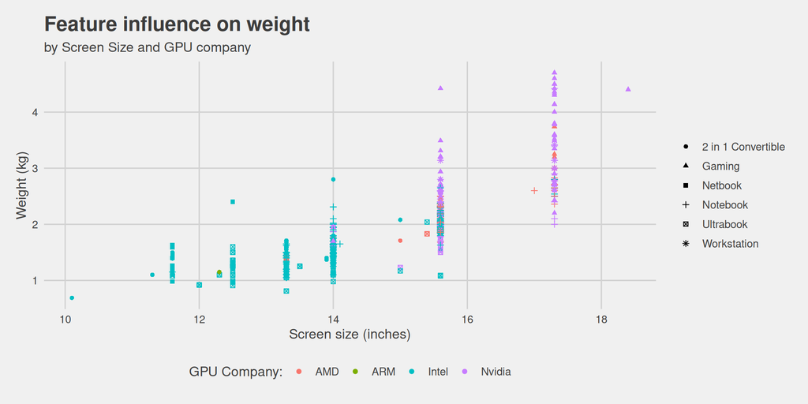

```r
ggplot(graph_laptops, aes(y=Weight, x=Inches)) +
  geom_point(aes(color=GPU_company, shape=TypeName)) + labs(
    title = 'Feature influence on weight',
    subtitle = 'by Screen Size and GPU company',
  ) + theme_fivethirtyeight() +
  theme(
    legend.position='bottom',
    axis.title.x = element_text(),
    axis.title.y = element_text()) +
  guides(
    color=guide_legend('GPU Company:'),
    shape=guide_legend(' ', position='right', direction='vertical')
  ) + xlab('Screen size (inches)') + ylab('Weight (kg)')
```

An additional data insight that we can derive from this plot is that Nvidia almost exclusively produces GPUs for laptops with large screen sizes for the gaming market, while Intel powers the graphics chips for most screens smaller than 15.4”.

## 2.2 Examining pricing ranges by company

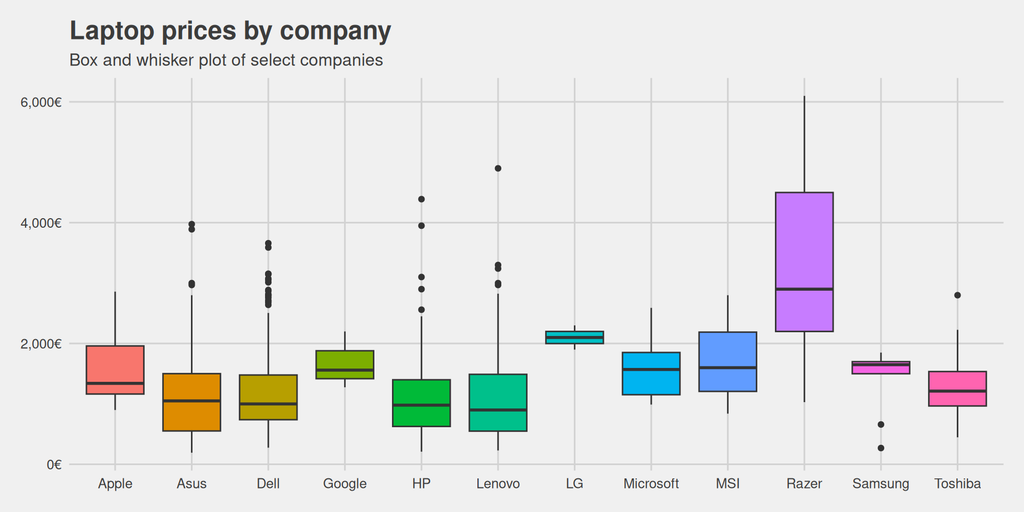

```r
graph_laptops |> ggplot(aes(x = Company, y = Price_euros, fill = Company)) + geom_boxplot() +
  labs(
  title = "Laptop prices by company",
  subtitle = "Box and whisker plot of select companies",
) + ylab('Price in Euros') +
    scale_y_continuous(labels = dollar_format(suffix="€", prefix = "")) +
    theme_fivethirtyeight() + theme(legend.position='none')
```

From the above box and whisker plot, we are able to quickly see the various price points of laptops by manufacturer. Razer operates primarily at the high range of the market with a significant range of price points for their products, while LG has a very narrow scope in terms of product price points.

## 2.3 Mean pricing by type and company

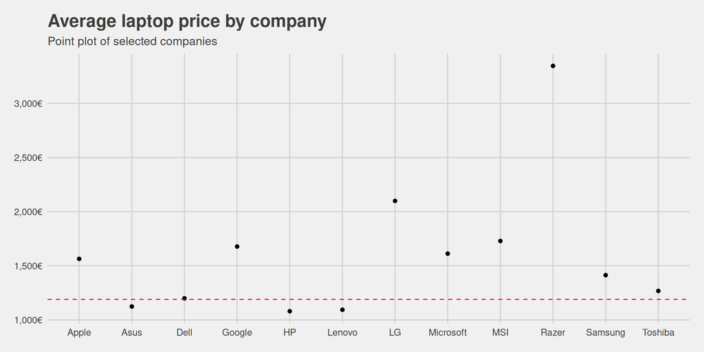

```r
overall_average <- graph_laptops |> summarize(mean(Price_euros, na.rm=TRUE))

average_by_brand <- graph_laptops |> group_by(Company) |> summarize(
  `Average Price` = mean(Price_euros, na.rm=TRUE),
  `Distance from Overall Average` = `Average Price` - overall_average[[1]]
)

average_plot <- average_by_brand |> ggplot(aes(y=`Average Price`, x=Company)) +
  geom_point() +
  labs(
  title = "Average laptop price by company",
  subtitle = "Point plot of selected companies"
) + scale_y_continuous(labels = dollar_format(suffix="€", prefix = "")) +
  ylab('Price in Euros')

average_plot + geom_hline(
  yintercept=overall_average[[1]],
  linetype='dashed',
  color='red') + theme_fivethirtyeight()
```

The above plot shows that Razer has the highest average cost of any company, while Dell is statistically equivalent to the mean price across all laptop manufacturers.

```r
summary_table_company <- laptops |> group_by(Company) |> summarize(
  `Average Price for Company (€)` = round(mean(Price_euros, na.rm=TRUE), 2),
  `Minimum (€)` = min(Price_euros, na.rm=TRUE),
  `Maximum (€)` = max(Price_euros, na.rm=TRUE),
  `Range (€)` = max(Price_euros, na.rm=TRUE) - min(Price_euros, na.rm=TRUE)
)

reactable(arrange(summary_table_company, summary_table_company$`Average Price for Company (€)`), defaultPageSize = 5)
```

| Company | Average Price for Company (€) | Minimum (€) | Maximum (€) | Range (€) |
| --- | --- | --- | --- | --- |
| Vero | 217.43 | 196 | 260 | 64 |
| Mediacom | 295 | 239 | 389 | 150 |
| Chuwi | 314.3 | 244.99 | 449 | 204.01 |
| Acer | 633.46 | 174 | 2599 | 2425 |
| Fujitsu | 729 | 649 | 799 | 150 |
| HP | 1080.31 | 209 | 4389 | 4180 |
| Lenovo | 1093.86 | 229 | 4899 | 4670 |
| Asus | 1123.83 | 191.9 | 3975 | 3783.1 |
| Xiaomi | 1133.46 | 935 | 1399.95 | 464.95 |
| Dell | 1199.23 | 274.9 | 3659.4 | 3384.5 |

[output cut: 9 more lines]

```r
summary_table_type <- laptops |> group_by(TypeName) |> summarize(
  `Average Price for Type of Laptop (€)` = round(mean(Price_euros, na.rm=TRUE), 2),
  `Minimum (€)` = min(Price_euros, na.rm=TRUE),
  `Maximum (€)` = max(Price_euros, na.rm=TRUE),
  `Range (€)` = max(Price_euros, na.rm=TRUE) - min(Price_euros, na.rm=TRUE)
)

reactable(arrange(summary_table_type, summary_table_type$`Average Price for Type of Laptop (€)`), defaultPageSize = 6)
```

| TypeName | Average Price for Type of Laptop (€) | Minimum (€) | Maximum (€) | Range (€) |
| --- | --- | --- | --- | --- |
| Netbook | 673.38 | 174 | 1908 | 1734 |
| Notebook | 788.74 | 196 | 4899 | 4703 |
| 2 in 1 Convertible | 1289.71 | 275 | 2824 | 2549 |
| Ultrabook | 1556.68 | 499 | 3100 | 2601 |
| Gaming | 1731.38 | 699 | 6099 | 5400 |
| Workstation | 2280.36 | 1369 | 4389 | 3020 |

# 3 Modeling

For the initial model, I am interested in a tuned lasso-ridge regression that identifies the strongest predictors of laptop pricing. The model will utilize a tuning grid to find the optimal penalty and split parameters. To evaluate the model quality, we will capture MAPE and RMSE. I selected MAPE because it was measured in an absolute percentage value, which I thought would be a helpful and quick way of comparing models to one another.

```r
# Split based on price for training and testing
test_split <- initial_split(
  laptops,
  strata = 'Price_euros'
)

laptop_train <- training(test_split)
laptop_test <- testing(test_split)

# Cross-validation split
cv_split <- vfold_cv(
  laptop_train,
  v = 10,
  strata = 'Price_euros'
)

# Build our initial recipe. We will remove the 'Product' name as an indicator.
rec_laptops <- recipe(Price_euros ~ . , data = laptop_train) |>
  step_rm(Product) |>
  step_novel(all_nominal_predictors(), new_level='unseen') |>
  step_unknown(all_nominal_predictors(), new_level='missing') |>
  step_other(all_nominal_predictors(), other='misc') |>
  step_normalize(all_numeric_predictors()) |>
  step_nzv(all_predictors()) |>
  step_dummy(all_nominal_predictors(), one_hot = TRUE)

# We will fine-tune for values for penalty and mixture
spec_laptops <- linear_reg(engine='glmnet', penalty=tune(), mixture=tune())

# Set up our workflow
flow_laptops <- workflow(preprocessor = rec_laptops, spec_laptops)

# Set up our tuning grid
grid_laptops <- flow_laptops |>
  extract_parameter_set_dials() |> grid_random(size=100)

# Set model quality for RMSE and MAPE
model_quality <- metric_set(rmse, mape)

# Model tuning
tune_laptops <- tune_grid(
  flow_laptops,
  resamples=cv_split,
  grid=grid_laptops,
  metrics=model_quality,
  control=control_grid(verbose=FALSE)
)

# Finalize with the selected best using MAPE
model_laptops_mape <- finalize_workflow(
  x=flow_laptops,
  parameters=tune_laptops |> select_best(metric='mape')
)

model_laptops_mape
```

```
══ Workflow ════════════════════════════════════════════════════════════════════
Preprocessor: Recipe
Model: linear_reg()

── Preprocessor ────────────────────────────────────────────────────────────────
7 Recipe Steps

• step_rm()
• step_novel()
• step_unknown()
• step_other()
• step_normalize()
• step_nzv()
• step_dummy()

── Model ───────────────────────────────────────────────────────────────────────
Linear Regression Model Specification (regression)

Main Arguments:
  penalty = 0.91819017659075
  mixture = 0.956366989028174

Computational engine: glmnet
```

```r
# Finalize with the selected best using RMSE
model_laptops_rmse <- finalize_workflow(
  x=flow_laptops,
  parameters=tune_laptops |> select_best(metric='rmse')
)

model_laptops_rmse
```

```
══ Workflow ════════════════════════════════════════════════════════════════════
Preprocessor: Recipe
Model: linear_reg()

── Preprocessor ────────────────────────────────────────────────────────────────
7 Recipe Steps

• step_rm()
• step_novel()
• step_unknown()
• step_other()
• step_normalize()
• step_nzv()
• step_dummy()

── Model ───────────────────────────────────────────────────────────────────────
Linear Regression Model Specification (regression)

Main Arguments:
  penalty = 3.11946239232536e-06
  mixture = 0.959754619270097

Computational engine: glmnet
```

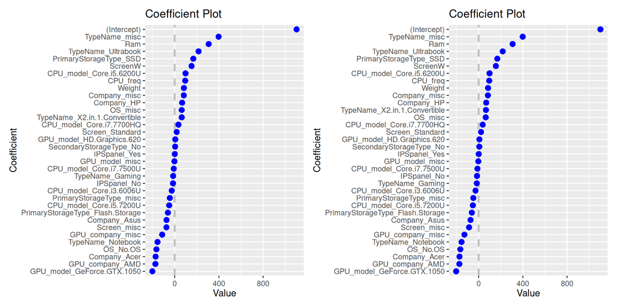

```r
# Fit and extract engine to generate coefficient plots
best_fit_laptops_mape <- model_laptops_mape |> fit(data=laptop_train)
coef_mape <- best_fit_laptops_mape |> extract_fit_engine() |> coefplot(sort='magnitude')

best_fit_laptops_rmse <- model_laptops_rmse |> fit(data=laptop_train)
coef_rmse <- best_fit_laptops_rmse |> extract_fit_engine() |> coefplot(sort='magnitude')

# Display the coefficient plots using patchwork
coef_mape + coef_rmse
```

```r
# Predict the prices for our held-back testing data on our MAPE model
predict_price <- predict(best_fit_laptops_mape, new_data = laptop_test, type="numeric")

# Generate a tibble with our results and the original product name/price to compare
predict_price_results <- laptop_test |> select(Product, Price_euros) |> bind_cols(predict_price)
predict_price_results$error <- predict_price_results$Price_euros - predict_price_results$.pred

# Show the results tibble
reactable(predict_price_results, defaultPageSize = 5)
```

| Product | Price_euros | .pred | error |
| --- | --- | --- | --- |
| MacBook Pro | 1803.6 | 1988.45513705558 | -184.855137055575 |
| XPS 13 | 979 | 1233.51246221284 | -254.512462212843 |
| Legion Y520-15IKBN | 999 | 1043.02116739308 | -44.021167393078 |
| MacBook Air | 1099 | 975.319437414819 | 123.680562585181 |
| 17-ak001nv (A6-9220/4GB/500GB/Radeon | 439 | 690.101176528307 | -251.101176528307 |
| IdeaPad 120S-14IAP | 249 | 87.7781246282145 | 161.221875371785 |
| Inspiron 5770 | 979 | 852.845749235427 | 126.154250764573 |
| X751NV-TY001T (N4200/4GB/1TB/GeForce | 466 | 383.822933320648 | 82.1770666793519 |
| X541UA-DM1897 (i3-6006U/4GB/256GB/FHD/Linux) | 415 | 719.767504473175 | -304.767504473175 |
| Inspiron 5770 | 1299 | 1336.71239466148 | -37.7123946614765 |

[output cut: 309 more lines]

```r
# Evaluate the average error in euro
mean(abs(predict_price_results$error))
```

```
[1] 255.5081
```

## 3.1 Manually creating a coefficient plot - summarized fit

I spent some time looking at the coefficient plot auto-graphing capabilities and wanted to explore the possibility of creating a manual coefficient plot with `ggplot`. Given the time constraints, I chose to use the summarized mean for each coefficient value of the best fit model.

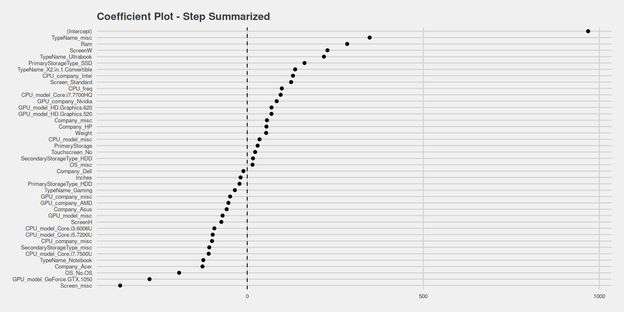

```r
tidy_bf <- best_fit_laptops_mape |> extract_fit_engine()
tidy_bf <- tidy(tidy_bf)
tidy_bf_sum <- group_by(tidy_bf, term) |> summarize(estimate = mean(.data$estimate))

# Create a coefficient plot. Drop the predictors that are close to zero (+/- 10 euros)
tidy_bf_sum |> filter(estimate < -10 | estimate > 10) |>  mutate(
  term = fct_reorder(term, estimate)) |>
  ggplot(aes(estimate, term)) +
  geom_point() +
  geom_vline(xintercept = 0, lty = 2) +
  labs(
    x = 'Value',
    y = NULL,
    title = 'Coefficient Plot - Step Summarized'
  ) + theme_fivethirtyeight() + theme(
    text = element_text(
      size=8,
  ))
```

## 3.2 Comparison to fewer predictors

I was interested to see how narrowing down the model to a select few variables would differ in terms of the model quality. I selected the `Price_euros`, `Ram`, `ScreenW`, `ScreenHeight`, `Company`, `TypeName`, and `OS` as potential predictors, reflecting likely characteristics that people might consider when making purchasing decisions.

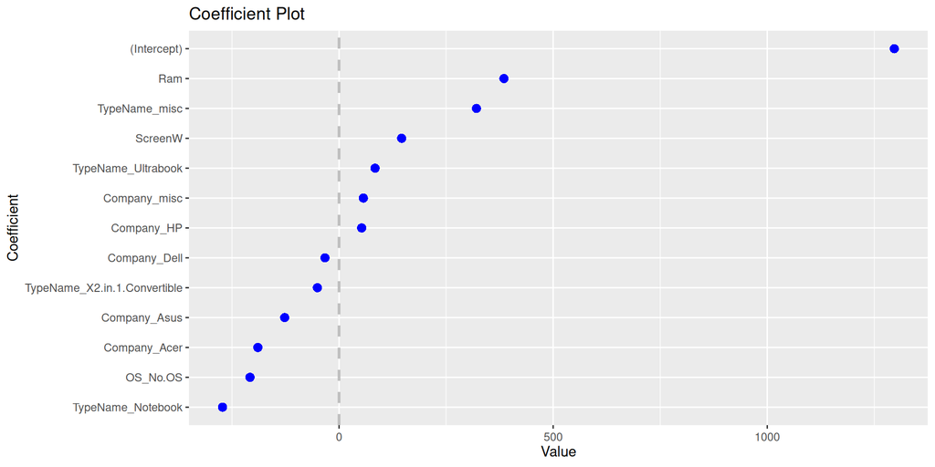

```r
# Create a new recipe with selected predictors
simple_laptop_recipe <- recipe(Price_euros ~ Ram + ScreenW + ScreenH + Company + TypeName + OS, data=laptop_train) |>
  step_novel(all_nominal_predictors(), new_level='unseen') |>
  step_unknown(all_nominal_predictors(), new_level='missing') |>
  step_other(all_nominal_predictors(), other='misc') |>
  step_normalize(all_numeric_predictors()) |>
  step_nzv(all_predictors()) |>
  step_dummy(all_nominal_predictors(), one_hot = TRUE)

# Set up workflow, grid, quality metrics
simple_laptop_flow <- workflow(preprocessor = simple_laptop_recipe, spec = spec_laptops)

simple_grid <- simple_laptop_flow |> extract_parameter_set_dials() |> grid_random(size=25)

model_quality <- metric_set(mape)

# Fine-tune penalty and mixture
tune_laptops_simple <- tune_grid(
  simple_laptop_flow,
  resamples=cv_split,
  grid=grid_laptops,
  metrics=model_quality,
  control=control_grid(verbose=FALSE)
)

# Finalize workflow
simple_model_laptops_mape <- finalize_workflow(
  x=simple_laptop_flow,
  parameters=tune_laptops_simple |> select_by_one_std_err(metric='mape', -penalty)
)

# Fit and plot
simple_best_fit_laptops <- simple_model_laptops_mape |> fit(data=laptop_train)
simple_best_fit_laptops |> extract_fit_engine() |> coefplot(sort='magnitude')
```

```r
# Predict on our held-back test data and combine into a new results tibble
predict_simple <- predict(simple_best_fit_laptops, new_data = laptop_test, type="numeric")
predict_simple_results <- laptop_test |> select(Product, Price_euros) |> bind_cols(predict_simple)
predict_simple_results$error <- predict_simple_results$Price_euros - predict_simple_results$.pred

# Display results
reactable(predict_simple_results, defaultPageSize = 5)
```

| Product | Price_euros | .pred | error |
| --- | --- | --- | --- |
| MacBook Pro | 1803.6 | 1587.22436142437 | 216.37563857563 |
| XPS 13 | 979 | 1310.22906826564 | -331.229068265642 |
| Legion Y520-15IKBN | 999 | 1286.08629033649 | -287.086290336492 |
| MacBook Air | 1099 | 1285.54708642529 | -186.547086425287 |
| 17-ak001nv (A6-9220/4GB/500GB/Radeon | 439 | 752.086474391859 | -313.086474391859 |
| IdeaPad 120S-14IAP | 249 | 535.707146227804 | -286.707146227804 |
| Inspiron 5770 | 979 | 930.844899798376 | 48.1551002016245 |
| X751NV-TY001T (N4200/4GB/1TB/GeForce | 466 | 367.331095104748 | 98.6689048952518 |
| X541UA-DM1897 (i3-6006U/4GB/256GB/FHD/Linux) | 415 | 571.721012754755 | -156.721012754755 |
| Inspiron 5770 | 1299 | 1528.24052120615 | -229.240521206152 |

[output cut: 309 more lines]

```r
mean(abs(predict_simple_results$error))
```

```
[1] 277.509
```

# 4 Summary

## 4.1 Learnings: Model Metrics

```r
tuning_metrics <- tune_laptops |> collect_metrics()
simple_metrics <- tune_laptops_simple |> collect_metrics()

tm <- tuning_metrics |> group_by(.metric) |> summarise(mean = mean(.data$mean), na.rm=TRUE)
sm <- simple_metrics |> group_by(.metric) |> summarise(mean=mean(.data$mean), na.rm=TRUE)
sm$.metric <- 'mape-simple'

metrics <- rbind(tm, sm)
kable(metrics)
```

| .metric | mean | na.rm |
| --- | --- | --- |
| mape | 28.17179 | TRUE |
| rmse | 341.90193 | TRUE |
| mape-simple | 31.03285 | TRUE |

## 4.2 Analysis of Step_Other Threshold

One difficulty in selecting a threshold for `step_other()` was that there were a significant difference in unique levels. With the default (`threshold = 0.05`), one of the most influential coefficients was `TypeName_misc`. Experimenting with different values (`threshold=20`) revealed that this was due to `TypeName_Workstation`’s influence on the model, but this value resulted in a huge number of coefficients across the CPU and GPU models.

```r
names_unique <- c('Unique GPU Models', 'Unique CPU Models', 'Unique Types')
data_unique <- c(length(unique(laptops$GPU_model)), length(unique(laptops$CPU_model)), length(unique(laptops$TypeName)))

unique_tb <- data.frame(names_unique, data_unique)
names(unique_tb) <- c('Descriptor', 'Count')
kable(unique_tb)
```

| Descriptor | Count |
| --- | --- |
| Unique GPU Models | 106 |
| Unique CPU Models | 93 |
| Unique Types | 6 |

## 4.3 Surprising Find: Gaming Laptops

I was surprised that gaming laptops were negatively correlated to price. My intuition would have been that gaming laptops would have better graphics cards, and subsequently cost more, but it turns out that it is slightly negatively correlated.

## 4.4 Surprising Find: Lenovo Pricing

I was surprised to find that the average price of a Lenovo laptop was below the overall mean. I have observed many organizations that procure Lenovo laptops for their employees, and would have assumed that the laptops were above the average cost due to the nature of enterprise sales. As a result of the finding, I’m more aware of how each company may be pricing along their respective “value stick”, and that perhaps Lenovo laptops are so popular in enterprise settings as a result of their price relative to longevity and/or performance.

## 4.5 Surprising Find: AMD GPUs

Prior to building these models, I would have hypothesized that AMD and Nvidia `GPU_company` values would have been positively correlated with price. I was surprised to find that Nvidia was not a meaningful factor at all, while AMD was negatively correlated with price.

```r
length(which(laptops$GPU_company=='AMD'))
```

```
[1] 174
```

```r
length(which(laptops$GPU_company=='Nvidia'))
```

```
[1] 396
```

I thought perhaps that AMD had very few occurrances in the dataset, but it looks to be a bit more than 10% of the total laptops in the dataset.

# 5 Bonus Model

Can we predict whether or not a computer is an Ultrabook or Notebook? This additional model uses logistic regression to choose a binary outcome for whether or not a laptop is likely to be a high-end Ultrabook, or a low-cost Notebook.

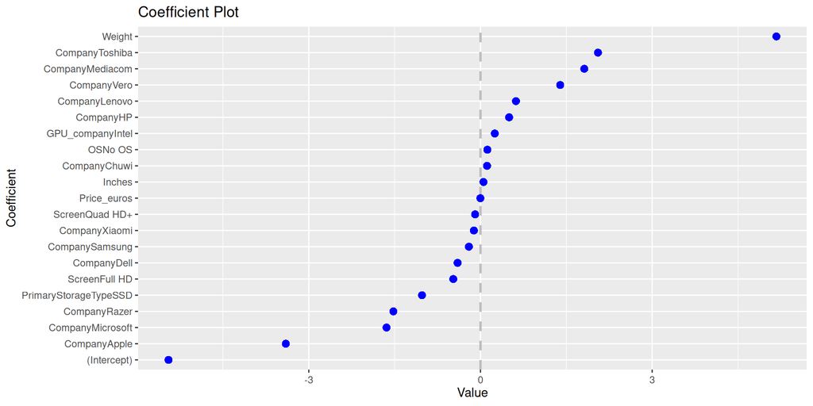

```r
laptop_subset <- filter(laptops, laptops$TypeName %in% c('Ultrabook', 'Notebook'))
laptop_subset <- select(laptop_subset, c('Company','OS', 'TypeName', 'Inches', 'Ram', 'Weight', 'Price_euros', 'Screen', 'Touchscreen', 'RetinaDisplay', 'PrimaryStorageType', 'GPU_company') )
laptop_subset$TypeName <- as_factor(laptop_subset$TypeName)

set.seed(13)
subset_split <- initial_split(
  laptop_subset,
  strata = 'TypeName'
)

subset_train <- training(subset_split)
subset_test <- testing(subset_split)


simple_model <- logistic_reg(engine='glmnet', penalty=0.01) |>
  fit(as_factor(TypeName) ~ ., data=subset_train)

coefplot(simple_model |> extract_fit_engine(), sort='magnitude')
```

```r
reactable(tidy(simple_model))
```

| term | estimate | penalty |
| --- | --- | --- |
| (Intercept) | -3.83032920996251 | 0.01 |
| CompanyApple | -2.31058004606756 | 0.01 |
| CompanyAsus | 0 | 0.01 |
| CompanyChuwi | 0 | 0.01 |
| CompanyDell | -0.501642548112972 | 0.01 |
| CompanyFujitsu | 0 | 0.01 |
| CompanyGoogle | 0 | 0.01 |
| CompanyHP | 0 | 0.01 |
| CompanyHuawei | 0 | 0.01 |
| CompanyLenovo | 0.0439814279651597 | 0.01 |

[output cut: 29 more lines]

```r
predict_ultrabook <- predict(simple_model, new_data = subset_test, type="class")
# Class Probabilities
probability_ultrabook <- predict(simple_model, new_data = subset_test, type = "prob")

prediction_results <- subset_test |> select(TypeName) |> bind_cols(predict_ultrabook, probability_ultrabook)
reactable(prediction_results)
```

| TypeName | .pred_class | .pred_Ultrabook | .pred_Notebook |
| --- | --- | --- | --- |
| Ultrabook | Ultrabook | 0.968964219495037 | 0.0310357805049633 |
| Ultrabook | Ultrabook | 0.520470247107822 | 0.479529752892178 |
| Notebook | Notebook | 0.0180101312791668 | 0.981989868720833 |
| Ultrabook | Ultrabook | 0.909083799324207 | 0.090916200675793 |
| Ultrabook | Ultrabook | 0.990763325390285 | 0.00923667460971474 |
| Notebook | Notebook | 0.0047012103748646 | 0.995298789625135 |
| Ultrabook | Ultrabook | 0.761280463964578 | 0.238719536035422 |
| Notebook | Notebook | 0.00427661929656786 | 0.995723380703432 |
| Ultrabook | Notebook | 0.205369577566112 | 0.794630422433888 |
| Notebook | Notebook | 0.00228187603258379 | 0.997718123967416 |

[output cut: 216 more lines]

```r
reactable(accuracy(prediction_results, truth = TypeName, estimate = .pred_class))
```

| .metric | .estimator | .estimate |
| --- | --- | --- |
| accuracy | binary | 0.942477876106195 |

This exercise demonstrates the power of market segmentation. The extremely high predictability success of an Ultrabook vs. a Notebook laptop shows that there were likely careful considerations put into play about to market a high end consumer offering vs. a more affordable option. From the coefficients, we can see that a laptop’s weight is the strongest predictor as to whether or not a laptop is a Notebook (heavier) or Ultrabook (lighter).